# Beverlyn Tucker IST736_Text_Mining_NLP_WK1

## Beverlyn Tucker

```
IST736_ Text Mining WK1
Professor: Dr. Ami Gates
```

## INTRODUCTION

Text mining and natural language processing (NLP), analytical studies can often approach using various methods. Furthermore, the general basis of text mining involves the counting of words typically. Having numerical counts in nested arrays allows the transformation of textual data to operated by various modeling methodologies. Analysts often make decisions regarding data preparation through analysis. However, reporting deadlines often require analysts to leverage experience to make relevant business decisions.

The question may raise what aspects of a study need careful planning? The ability to accurately manage time enables more complex segments (often analysis related) to obtain significant decisions for a meaningful outcome. In general, practice data analysts and scientists need to be comfortable with the tools required for data preparation. These include familiarity and comprehension with capabilities to ingest data and knowledge of the "right" tools for the corresponding analysis. Having the expertise and insight to accomplish these tasks, enable the analyst to spend more time on the critical elements that build the report.

## Data Preparation

```python
##import string
from collections import Counter
import pandas as pd
import re
import matplotlib.pyplot as plt
from nltk.corpus import stopwords
from nltk.sentiment.vader import SentimentIntensityAnalyzer
from nltk.stem import WordNetLemmatizer
from nltk.tokenize import word_tokenize
import nltk
import seaborn as sns
nltk.download('vader_lexicon')
from nltk.sentiment.vader import SentimentIntensityAnalyzer
sid = SentimentIntensityAnalyzer()
from textblob import TextBlob
from wordcloud import WordCloud
```

```python
df =pd.read_csv('C:/Users/bevst/Downloads/IST736/WK1/AI_Tweets_R2.csv',encoding='cp1252')
```

```python
df =pd.read_csv('C:/Users/bevst/Downloads/IST736/WK1/AI_Tweets.csv',encoding='cp1252')
```

```python
df.columns
```

```
Index(['user', 'timestamp', 'text'], dtype='object')
```

```python
df.drop(['user'], axis=1, inplace = True)
```

```python
df=df.rename(columns={'text':'tweets'})
df
```

|  | timestamp | tweets |
| --- | --- | --- |
| 0 | 12/26/2011 22:44 | Artificial Intelligence Is Going To Be The End... |
| 1 | 1/14/2019 23:20 | The Weaponization Of Artificial Intelligence #... |
| 2 | 1/14/2019 23:25 | The Weaponization Of Artificial Intelligence #... |
| 3 | 5/6/2011 18:53 | @TheChameleon84 wow. I hate Artificial Intelli... |
| 4 | 7/19/2014 21:50 | this artificial intelligence performance kind ... |
| ... | ... | ... |
| 196 | 5/24/2018 23:50 | Artificial intelligence can now be used to kee... |
| 197 | 9/14/2010 12:26 | Forex trading service guarantees 99.9% profita... |
| 198 | 6/2/2009 2:21 | I had forgotten how much I liked that movie,"A... |
| 199 | 7/19/2014 23:21 | What are prominent positive examples of strong... |
| 200 | 6/2/2009 3:53 | Man, I forgot how good Artificial Intelligence... |

201 rows × 2 columns

```python
# Start with one review:
from wordcloud import WordCloud, STOPWORDS, ImageColorGenerator
text = df.tweets[0]
stopwords = set(STOPWORDS)
# Create and generate a word cloud image:
stopwords.update(["wPk7QWpK8Z", "co", "https"])
wordcloud = WordCloud(stopwords=stopwords, background_color="black").generate(text)
```

## Data Cleaning

Utilize wordcloud function to remove stop words and for data mugging and show the word cloud visualization. "wPk7QWpK8Z", "co", "https"."https","http","@", "I","and","#"

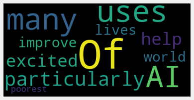

```python
# Start with one review:
from wordcloud import WordCloud, STOPWORDS, ImageColorGenerator
text = df.tweets[0]
stopwords = set(STOPWORDS)
# Create and generate a word cloud image:
stopwords.update(["wPk7QWpK8Z", "co", "https"])
wordcloud = WordCloud(stopwords=stopwords, background_color="black").generate(text)

# Display the generated image:
plt.imshow(wordcloud, interpolation='bilinear')
plt.axis("off")
plt.show()
```

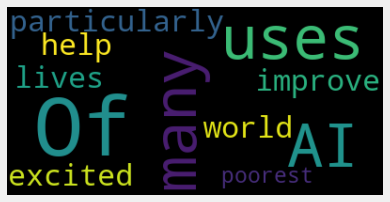

```python
# Start with one review:
from wordcloud import WordCloud, STOPWORDS, ImageColorGenerator
df = df.tweets[1]
stopwords = set(STOPWORDS)
# Create and generate a word cloud image:
stopwords.update(["https","http","@", "I","and","#",])

wordcloud = WordCloud(stopwords=stopwords, background_color="black").generate(text)
# Display the generated image:
plt.imshow(wordcloud, interpolation='bilinear')
plt.axis("off")
plt.show()
```

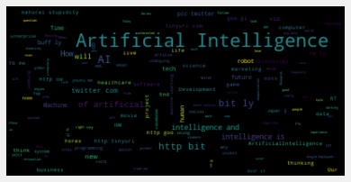

```python
# Start with one review:
#text = mdf.Tweet_Text[1]7370
text= " ".join(review for review in df.tweets)
# Create stopword list:

stopwords.update(["https", "CO", "amp", "one","Im","said","the"])


# Create and generate a word cloud image:
#wordcloud = WordCloud().generate(text)
# Generate a word cloud image
wordcloud = WordCloud(stopwords=stopwords, background_color="black").generate(text)

# Display the generated image:
plt.imshow(wordcloud, interpolation='bilinear')
plt.axis("off")
plt.show()
```

```python
#Function to get Subjectivity
def getSubjectivity(text):
    return TextBlob(text).sentiment.subjectivity

#Function to get Polarity
def getpolarity(text):
    return TextBlob(text).sentiment.polarity

#create a new colums
df['Subjectivity'] = df['tweets'].apply(getSubjectivity)
df['Polarity'] = df['tweets'].apply(getpolarity)
df.head()
```

|  | timestamp | tweets | Subjectivity | Polarity |
| --- | --- | --- | --- | --- |
| 0 | 12/26/2011 22:44 | Artificial Intelligence Is Going To Be The End... | 1.000000 | -0.600000 |
| 1 | 1/14/2019 23:20 | The Weaponization Of Artificial Intelligence #... | 1.000000 | -0.600000 |
| 2 | 1/14/2019 23:25 | The Weaponization Of Artificial Intelligence #... | 1.000000 | -0.600000 |
| 3 | 5/6/2011 18:53 | @TheChameleon84 wow. I hate Artificial Intelli... | 0.966667 | -0.358333 |
| 4 | 7/19/2014 21:50 | this artificial intelligence performance kind ... | 0.866667 | -0.200000 |

```python
def getAnalysis(score):
    if score <0:
        return  'Negative'
    elif score ==0:
        return 'Neutral'
    else:
        return 'Positive'


df['Analysis'] = df['Polarity'].apply(getAnalysis)

#Show new data frame
df.head()
```

[output not shown]

## Subjectivity and Polarity analysis

Classifying public expression on how artificial intelligence(AI) evolve in today's generation. Identify the polarity as positive, neutral, and negative each sentiment or opinions and assigns labels to the document based on the aggregate score.

```python
#Function to get Subjectivity
def getSubjectivity(text):
    return TextBlob(text).sentiment.subjectivity

#Function to get Polarity
def getpolarity(text):
    return TextBlob(text).sentiment.polarity

#create a new colums
df['Subjectivity'] = df['tweets'].apply(getSubjectivity)
df['Polarity'] = df['tweets'].apply(getpolarity)



def getAnalysis(score):
    if score <0:
        return  'Negative'
    elif score ==0:
        return 'Neutral'
    else:
        return 'Positive'


df['Analysis'] = df['Polarity'].apply(getAnalysis)

#Show new data frame
df.head()
```

|  | timestamp | tweets | Subjectivity | Polarity | Analysis |
| --- | --- | --- | --- | --- | --- |
| 0 | 12/26/2011 22:44 | Artificial Intelligence Is Going To Be The End... | 1.000000 | -0.600000 | Negative |
| 1 | 1/14/2019 23:20 | The Weaponization Of Artificial Intelligence #... | 1.000000 | -0.600000 | Negative |
| 2 | 1/14/2019 23:25 | The Weaponization Of Artificial Intelligence #... | 1.000000 | -0.600000 | Negative |
| 3 | 5/6/2011 18:53 | @TheChameleon84 wow. I hate Artificial Intelli... | 0.966667 | -0.358333 | Negative |
| 4 | 7/19/2014 21:50 | this artificial intelligence performance kind ... | 0.866667 | -0.200000 | Negative |

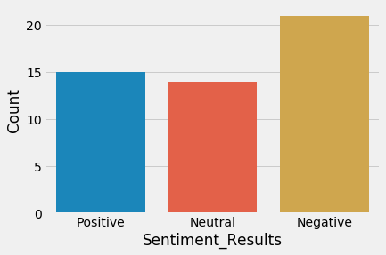

```python
sns.countplot('Analysis', data=df)
_ = plt.xlabel('Sentiment_Results')
_ = plt.ylabel('Count')
plt.show()
```

```python
##Change the string to integers modeling preparation

def getAnalysis(score):
    if score <0:
        return  0 ##'Negative'
    elif score ==0:
        return 1 ##'Neutral'
    else:
        return 2 ##'Positive'


df['Analysis'] = df['Polarity'].apply(getAnalysis)

#Show new data frame
df.head()
```

[output not shown]

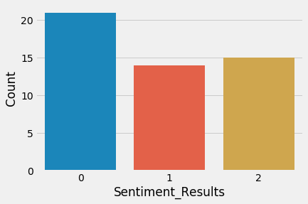

```python
sns.countplot('Analysis', data=df)
_ = plt.xlabel('Sentiment_Results')
_ = plt.ylabel('Count')
plt.show()
```

## Polarity and Subjectivity Analysis Results

Classifying public expression on how artificial intelligence (AI) evolve in today's generation. Identify the polarity as positive, neutral, and negative each sentiment or opinions and assigns labels to the document based on the aggregate score. First, looking at the data in the string, then convert to integers for modeling analysis.

## Splitting Data for Training and Test

The data shows that there was more public who are concern about artificial intelligence. The data are about equality distributed.

```python
df2=df ## change data name to df2 to prevent reprocessing and save time.
```

```python
from sklearn.model_selection import train_test_split
# Convert label back to int.
#df2['Analysis'] = df['Analysis'].astype('int')
# Split the data into train and test sets.
np.random.seed(42)
x_train, x_test, y_train, y_test = train_test_split(df2['tweets'], df2['Analysis'], test_size=0.33, random_state=5)
```

## Transform

Vectorize and transform the training and test by utilizing from sklearn.feature_extraction.text import TfidfVectorizer. With min depth of 2, max depth of 0.8 sublinear true and English stop word.

```python
from sklearn.feature_extraction.text import TfidfVectorizer

tf = TfidfVectorizer(min_df=2, max_df=0.8, sublinear_tf=True, use_idf=True, stop_words='english')


# Count and transform the training and testing sets.
x_train_tfidf = tf.fit_transform(x_train)
x_test_tfidf = tf.transform(x_test)
```

## SVM Model

Model1- SVM Model package use from sklearn.SVM import LinearSVC and use LinearSVC. 0- means negative, 1- neutral and 2- positive. The result shows more 0, which means it is negative connotation on AI.

```python
from sklearn.svm import LinearSVC

# Now to use an svm to create the model.
model1 = LinearSVC()
model1.fit(x_train_tfidf, y_train)
result1 = model1.predict(x_test_tfidf)
print(result1)
```

```
[2 1 0 0 1 0 1 2 0 0 1 0 1 1 0 0 2]
```

## NLTK classifier Model2

```python
import nltk
from nltk.classify import SklearnClassifier

nltkTrain = x_train.index.values
nltkTest = x_test.index.values
train = df2.iloc[nltkTrain, [0, 3]]
test = df2.iloc[nltkTest, [0, 3]]
```

```python
train
```

|  | tweets | Analysis |
| --- | --- | --- |
| 34 | Slovenia to Set Up International AI Research C... | 1 |
| 37 | Want to ride along with Robocar? Make sure to ... | 2 |
| 26 | Agree re #AI, #robotics and #disruption. But t... | 2 |
| 41 | Artists are using artificial intelligence to m... | 0 |
| 33 | The market for #DeepLearning chipsets will inc... | 1 |
| 24 | Would you rather: be killed by Robots on purpo... | 0 |
| 10 | Technology is awesome and can help us solve ma... | 2 |
| 44 | Your next car might come with an #AI personal ... | 1 |
| 25 | Experts warn of potential harmful effects of a... | 0 |
| 18 | How we can prepare now for catastrophically da... | 0 |
| 22 | This is the wrong approach. AI cannot police c... | 0 |
| 20 | YouTube's AI recommendation system tends to re... | 1 |
| 49 | This #robot makes threading a needle looks easy | 2 |
| 1 | Join us in San Francisco April 23-25 at the la... | 1 |
| 11 | Scientists have raised some red flags by devel... | 0 |
| 13 | Image-net is mentioned all the time in ML/AI a... | 1 |
| 40 | Young Astronomer Uses Artificial Intelligence ... | 0 |
| 46 | Jack Ma thinks #AI is going to cause more pain... | 2 |
| 15 | AI isn't dangerous, but human bias is | 0 |
| 12 | Elon Musk-funded AI text generator was too dan... | 0 |
| 7 | Sad and dangerous. Petty politics means Google... | 0 |
| 45 | AI is on track to generate $15 trillion in glo... | 2 |
| 30 | Microsoft CEO Nadella meets with top execs eve... | 2 |
| 27 | Want to sneak fake, extremeist content into my... | 0 |
| 39 | This #Robot rides a bike like a #Human | 1 |
| 36 | This Company is Going to Use AI to Market Thei... | 1 |
| 8 | As General Practice is being decimated & @Cons... | 0 |
| 9 | Artificial intelligence has the potential to b... | 0 |
| 16 | This is my same reservation w Machine Learning... | 0 |
| 38 | #Volvo has pioneered the autonomous garbage tr... | 2 |
| 47 | IBM CEO, Ginni Rometty is bullish on AI and th... | 2 |
| 14 | The US government has spent billions performin... | 0 |
| 35 | EasyEmail uses AI to autosuggest sentences as ... | 1 |

```python
test
```

|  | tweets | Analysis |
| --- | --- | --- |
| 42 | Amazon might one day deliver goods to your hom... | 2 |
| 29 | I can't tell what's weirder about this clip th... | 1 |
| 6 | #AI is helping to make dirty, dangerous, and d... | 0 |
| 19 | This continual "AI will save us from bad conte... | 0 |
| 28 | AI raises $13 million to train AI models effic... | 1 |
| 17 | I normally enjoy @FareedZakaria's technology s... | 0 |
| 2 | The UK is recognised worldwide for its creativ... | 2 |
| 43 | Momentum is growing to make #Montreal a centre... | 2 |
| 3 | If you're a human from any part of the world p... | 2 |
| 21 | Elon: AI is dangerous we need regulations or t... | 0 |
| 31 | It's proprietary so we can't explain how our A... | 1 |
| 4 | Mark my words A.I. is far more dangerous than ... | 1 |
| 32 | AI robots could assist soldiers in future | 1 |
| 0 | Of the many uses for AI, I’m particularly exci... | 2 |
| 23 | Humans should be very careful to prevent futur... | 0 |
| 5 | New AI fake text generator too dangerous to re... | 0 |
| 48 | 'Pure thought': Edmonton graduates using brain... | 2 |

```python
tweets = []
for index, row in train.iterrows():
    wordsFiltered = [e.lower() for e in row.tweets.split() if len(e) >= 2]
    wordsCleaned = [word for word in wordsFiltered
        if 'http' not in word
        and not word.startswith('@')
        and not word.startswith('#')
        and word != 'RT']
    tweets.append((wordsCleaned, row.Analysis))
```

```python
def getWordsTweets(tweets):
    all = []
    for (words, label) in tweets:
        all.extend(words)
    return all
def getWordFeatures(wordlist):
    wordlist = nltk.FreqDist(wordlist)
    features = wordlist.keys()
    return features
wFeatures = getWordFeatures(getWordsTweets(tweets))
def extractFeatures(document):
    docWords = set(document)
    features = {}
    for word in wFeatures:
        features['contains(%s)' % word] = (word in docWords)
    return features
# Splits the test set into positive, neutral, and negative to predict.
testPos = test[test['Analysis'] == 2]
testPos = testPos['tweets']
testNrl = test[test['Analysis']==1]
testNrl = testNrl['tweets']
testNeg = test[test['Analysis'] == 0]
testNeg = testNeg['tweets']
```

```python
# Build the second model.
trainingSet = nltk.classify.apply_features(extractFeatures,tweets)
model2 = nltk.NaiveBayesClassifier.train(trainingSet)
print(model2)
```

```
<nltk.classify.naivebayes.NaiveBayesClassifier object at 0x000001DD7F35BEC8>
```

```python
from sklearn.metrics import accuracy_score
# SVM results.
print('SVM Accuracy: %s ' % (accuracy_score(y_test, result1)))
# NLTK results.
negCnt = 0
nrlCnt = 0
posCnt = 0
for obj in testNeg:
    res = model2.classify(extractFeatures(obj.split()))
    if(res == 0):
        negCnt += 1
for obj in testNrl:
    res = model2.classify(extractFeatures(obj.split()))
    if(res == 1):
        nrlCnt += 1
for obj in testPos:
    res =  model2.classify(extractFeatures(obj.split()))
    if(res == 2):
        posCnt += 1
total = negCnt + nrlCnt + posCnt
print('NLTK Accuracy: %s ' % (total/len(test)))
print(negCnt)
print(nrlCnt)
print(posCnt)
```

```
SVM Accuracy: 0.7647058823529411
NLTK Accuracy: 0.35294117647058826
6
0
0
```

## Results

The SVM models have better accuracy compared to NLTK model. NLTK model has low accuracy scores. However, this may be due to either the size of the dataset or the data are not clean enough to predict the sentiment of the text accurately. SVM model produces a superior accuracy score as expected compared to the other model in text modeling—correctly predicting 76 percentiles.

## Conclusion

Conducting analysis frequently requires skills and the wisdom to select effective methodologies. Without applying foundational principles for data preparation and associated analysis, could risk time management. Simple procedures such as subsetting the original data could enable analysts to reduce development time, and concentrate more on acquiring significant results.

The tools are suitable for the task. Although, it required more time and attention to detail cleaning the data to build a model more capable of determining the overall sentiment of social media towards AI.